# Sampling and the Central Limit Theorem Part II

your name

2024-11-07

## Math 2265 Chapter 5. Foundations for Inference

### Section 5.1 Point Estimates and Sampling Variability

- Work as a group!
- You will need to replace `"ans"` or `your_answer` in the source code
- Update your name in L3
- Add your group members’ name below; students may lose points if Question 0 is unanswered
- Make sure you save and `knit` your work (to html or pdf) before submitting it to Canvas
- Please only submit your work if you attended the class and worked with other students; this is not an online course

### Goal

1. Understand the central limit theorem by example
2. Understand point estimates, standard errors, and the condidence interval

### Question 0. Who are your group members? (List their first names)

**Answer:**

1. `<name_1>`
2. `<name_2>`
3. `<name_3>`
4. `<name_4>`

### If you need more time to get used to `Markdown`, use the `Visual` mode.

The icon is located in the upper-left corner next to `source`.

# Normal distribution, Central Limit Theorem, Confidence Interval

These worksheets aim to help you understand the phrase such as “95% OF MEANS PROJECTED TO FALL IN THIS RANGE.” In a nutshell, we want to estimate the `mean (or proportion) of the population` from the `mean (or proportion) of a sample` with, often, 95% confidence.

In the last worksheet, we created a population of size 50,000 consisting of “successes” and “fails” and took 2,000 samples each of size 1,000. We used the mean of the distribution, consisting of the sample proportions (often denoted by $\hat{p}$, to estimate the population proportion $p = 0.66028$).

**Summary**

- Samples need not have the same proportions or the population proportion.
- However, the distribution of the sample proportions follows a normal distribution whose mean approxmates the population proportion.
  - This is a consequence of the central limit theorem.

Last time, we had a question of “will the mean be closer to the population proportion and the standard deviation will be smaller if we take more samples”. Be careful as there deal with two sizes:

- Size of each sample
- Number of samples we take

## Experiments

The following code block creates the population of our simulations.

```r
# the first two lines randomize the probability
set.seed(1105)
probabilities <- runif(2)
probabilities <- probabilities / sum(probabilities)

# generate population of size 50,000 consisting of successes and fails
population <-sample(c("success", "fail"), 50000, replace = TRUE, prob=probabilities)
population_proportion <- table(population)["success"]/50000
print(paste("The population parameter is", population_proportion))
```

```
## [1] "The population parameter is 0.66028"
```

### Varying the number of samples

In the following, we vary the number of samples we take with 100, 1,000, and 5,000 to support our answer experimentally.

#### 100 Samples

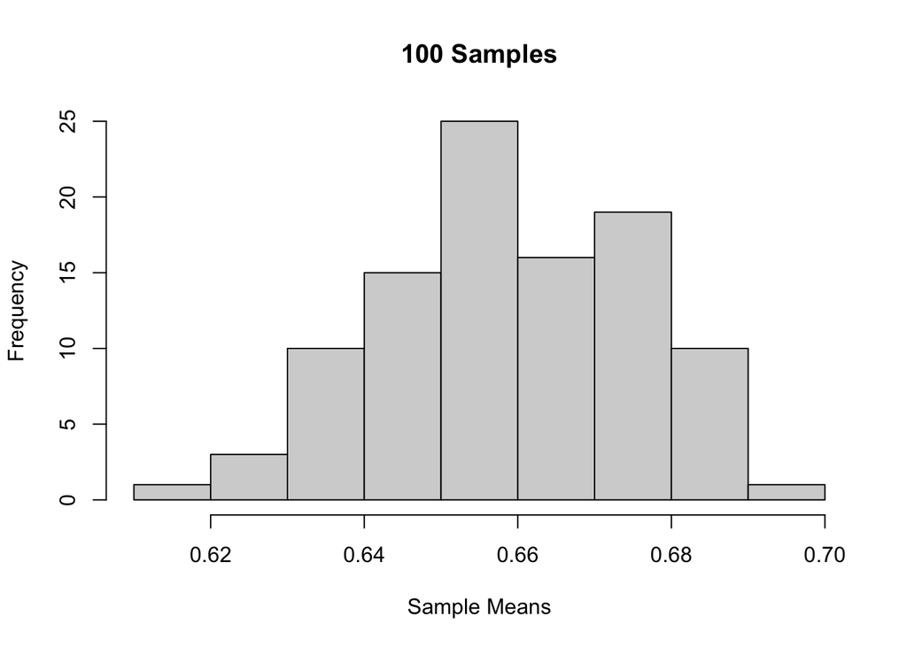

```r
number_of_samples <- 100
sample_means <- replicate(number_of_samples, table(sample(population, 1000))["success"])
sample_means <- sample_means / 1000
hist(sample_means, main="100 Samples", xlab="Sample Means")
```

```r
print(paste("The mean with", number_of_samples, "is", mean(sample_means)))
```

```
## [1] "The mean with 100 is 0.65976"
```

```r
print(paste("The error, point estimate - population parameter is", mean(sample_means) - population_proportion))
```

```
## [1] "The error, point estimate - population parameter is -0.000519999999999965"
```

1,000 Samples

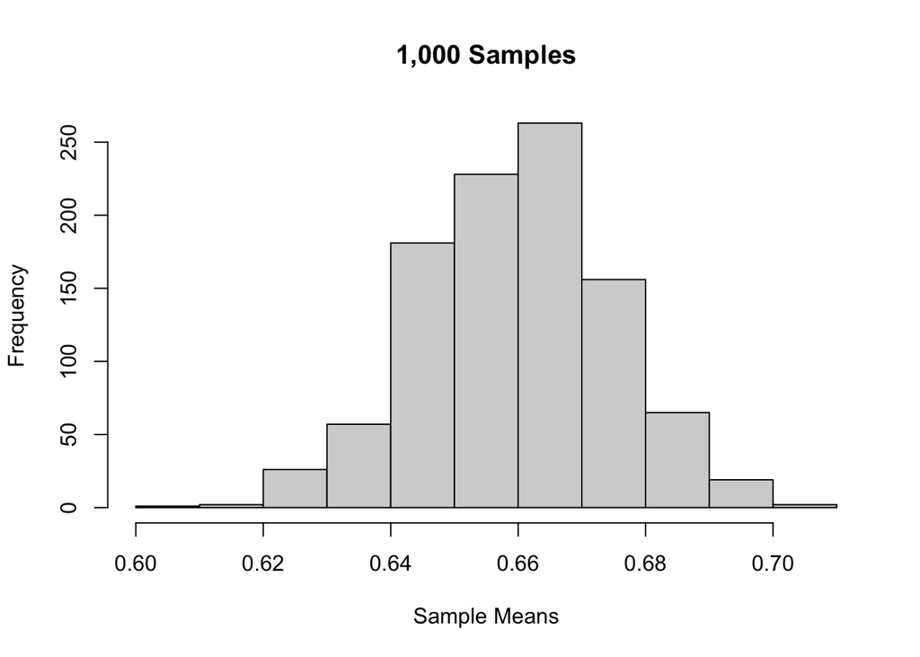

```r
number_of_samples <- 1000
sample_means <- replicate(number_of_samples, table(sample(population, 1000))["success"])
sample_means <- sample_means / 1000
hist(sample_means, main="1,000 Samples", xlab="Sample Means")
```

```r
print(paste("The mean with", number_of_samples, "is", mean(sample_means)))
```

```
## [1] "The mean with 1000 is 0.660207"
```

```r
print(paste("The error, point estimate - population parameter is", mean(sample_means) - population_proportion))
```

```
## [1] "The error, point estimate - population parameter is -7.29999999999897e-05"
```

5,000 Samples

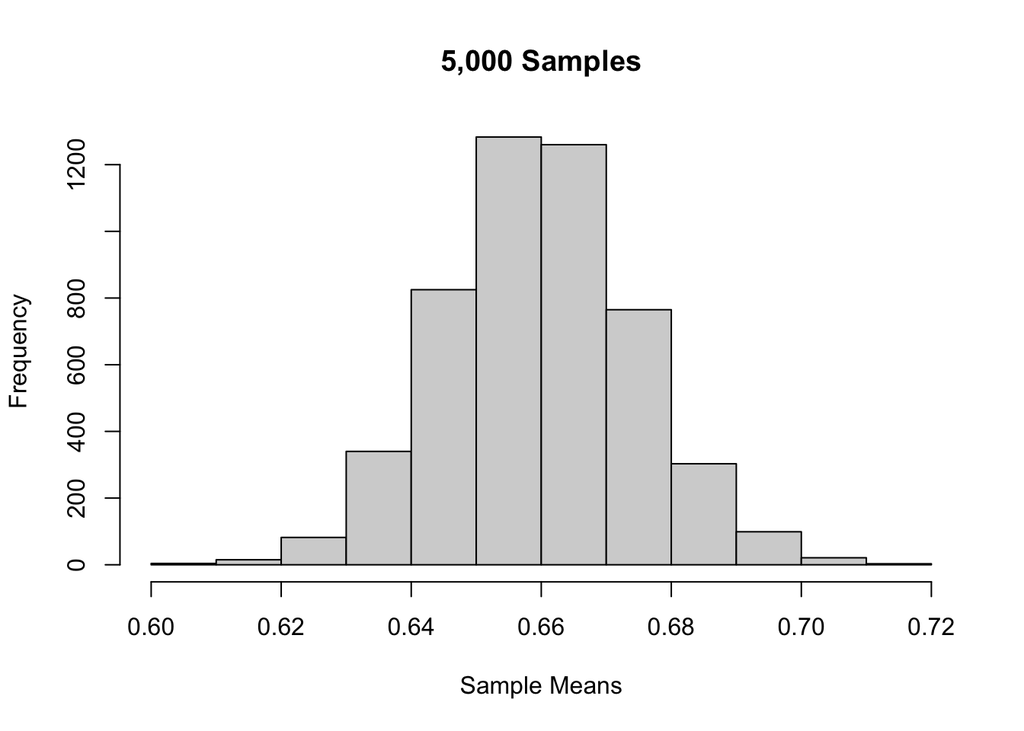

```r
number_of_samples <- 5000
sample_means <- replicate(number_of_samples, table(sample(population, 1000))["success"])
sample_means <- sample_means / 1000
hist(sample_means, main="5,000 Samples", xlab="Sample Means")
```

```r
print(paste("The mean with", number_of_samples, "is", mean(sample_means)))
```

```
## [1] "The mean with 5000 is 0.6602046"
```

```r
print(paste("The error, point estimate - population parameter is", mean(sample_means) - population_proportion))
```

```
## [1] "The error, point estimate - population parameter is -7.53999999999477e-05"
```

**Question**

1. What was the error with 100 samples? answer:
2. Are 100 samples enough to estimate the population proportion? (open-end question) answer:

### Varying the sample size

Now, we fix the number of samples at 100 and vary the observations in each sample to 50, and 500.

50 observations in each sample

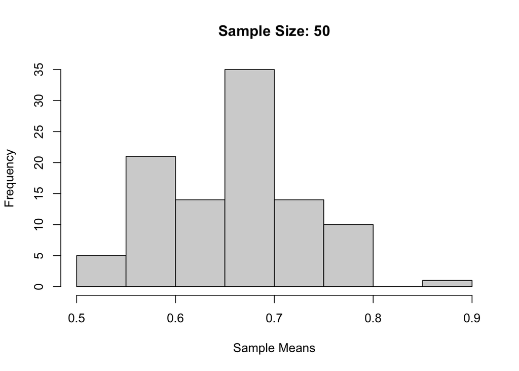

```r
number_of_samples <- 100
number_of_observations_in_sample <- 50
sample_means <- replicate(number_of_samples, table(sample(population, number_of_observations_in_sample))["success"])
sample_means <- sample_means / number_of_observations_in_sample
hist(sample_means, main="Sample Size: 50", xlab="Sample Means")
```

```r
print(paste("The mean with", number_of_samples, "is", mean(sample_means)))
```

```
## [1] "The mean with 100 is 0.6634"
```

```r
print(paste("The error, point estimate - population parameter is", mean(sample_means) - population_proportion))
```

```
## [1] "The error, point estimate - population parameter is 0.00312000000000001"
```

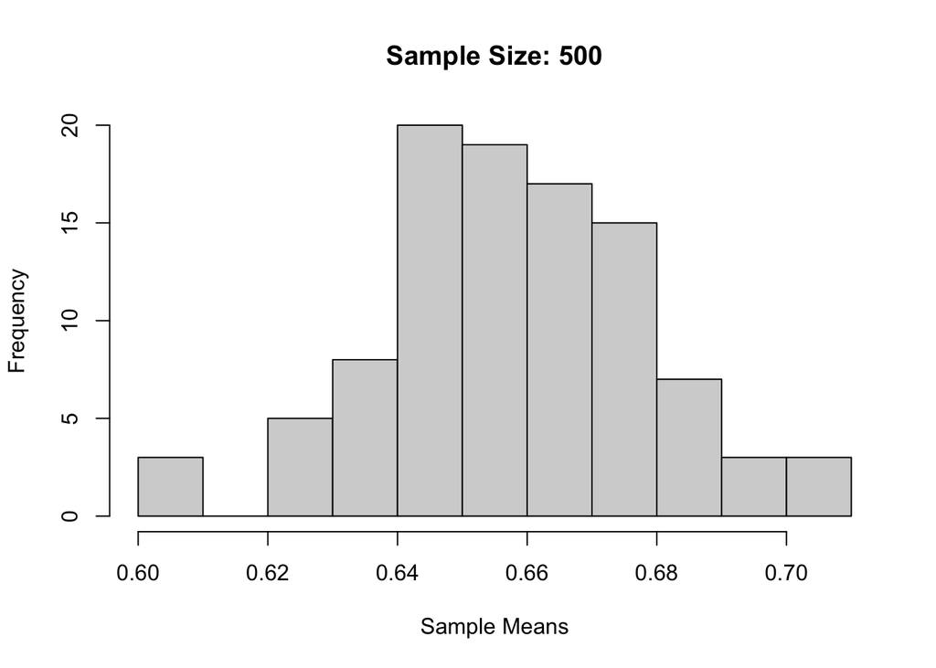

```r
number_of_samples <- 100
number_of_observations_in_sample <- 500
sample_means <- replicate(number_of_samples, table(sample(population, number_of_observations_in_sample))["success"])
sample_means <- sample_means / number_of_observations_in_sample
hist(sample_means, main="Sample Size: 500", xlab="Sample Means")
```

```r
print(paste("The mean with", number_of_samples, "is", mean(sample_means)))
```

```
## [1] "The mean with 100 is 0.65884"
```

```r
print(paste("The error, point estimate - population parameter is", mean(sample_means) - population_proportion))
```

```
## [1] "The error, point estimate - population parameter is -0.00144"
```

**Question:**

1. Did 50 observations in the samples provide a good estimate? (open-ended)
2. Or did 500 observation simulation provide a better result than that of 50 observation case?

## Task

In the next code block, choose your own number of samples and observations in samples. The goal is to choose the smallest number for the best approximation.

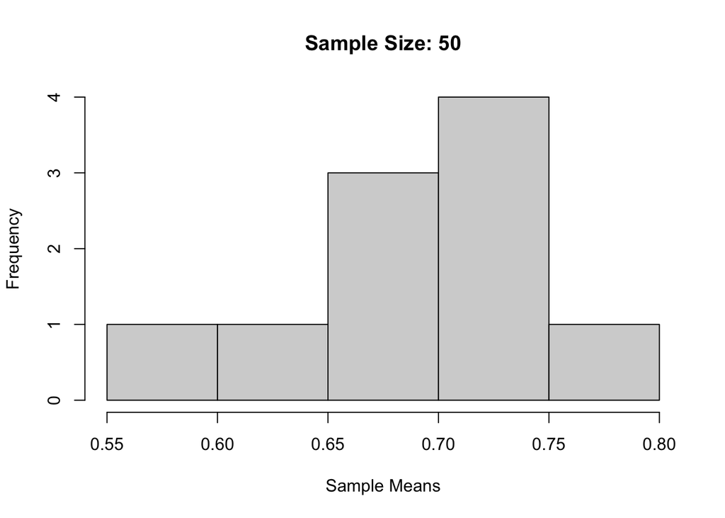

```r
number_of_samples <- 10                   #change this
number_of_observations_in_sample <- 50    #change this
sample_means <- replicate(number_of_samples, table(sample(population, number_of_observations_in_sample))["success"])
sample_means <- sample_means / number_of_observations_in_sample
hist(sample_means, main="Sample Size: 50", xlab="Sample Means")
```

```r
print(paste("The mean with", number_of_samples, "is", mean(sample_means)))
```

```
## [1] "The mean with 10 is 0.698"
```

```r
print(paste("The error, point estimate - population parameter is", mean(sample_means) - population_proportion))
```

```
## [1] "The error, point estimate - population parameter is 0.03772"
```

### Numerican variables

The population proportion in the example above was based on a categorical variable. The central limit theorem applies to numerical variables too. Next time we will an example.